# Temperature data option calculation

Finally we can check the distribution of the future datapoints and check it against the historical performance, we can see that the distribution takes on a different shape from the historical models there appears to be a reasonably good fit for your temperature forecast model:

- The general shape and spread of both distributions are well captured
- The seasonal separation is clearly maintained
- The peak positions are close to the historical data
- The overall temperature ranges match well

This is what goes on behind the scenes split into different components

```r
trading_dates_year <- seq(as.Date("2024-12-31"), as.Date("2025-12-31"), by = "day")

x_vals <- as.numeric(trading_dates_year) - as.numeric(trading_dates_year)[1]
Tbar_vals <- T_model(x_vals, a, b, alpha, theta)
dTbar_vals <- dT_model(x_vals, a, b, alpha, theta)
sigma_vals <- data.frame(vol_df)$fvol[yday(trading_dates_year)]

data.frame(
  x_vals = x_vals,
  Tbar_vals = Tbar_vals,
  dTbar_vals = dTbar_vals,
  sigma_vals = sigma_vals
) %>%
  show_df()
```

| DATE | x_vals | Tbar_vals | dTbar_vals | sigma_vals |
| --- | --- | --- | --- | --- |
| 1 | 0 | 2.718912 | -0.0884504 | 3.450746 |
| 2 | 1 | 2.631474 | -0.0864210 | 3.455030 |
| 3 | 2 | 2.546078 | -0.0843660 | 3.448123 |
| 4 | 3 | 2.462750 | -0.0822859 | 3.440245 |
| 5 | 4 | 2.381515 | -0.0801815 | 3.431344 |
| NA | NA | NA | NA | NA |
| 362 | 361 | 3.148446 | -0.0967760 | 3.392572 |
| 363 | 362 | 3.052625 | -0.0948620 | 3.404770 |
| 364 | 363 | 2.958732 | -0.0929199 | 3.416690 |
| 365 | 364 | 2.866794 | -0.0909503 | 3.428326 |
| 366 | 365 | 2.776840 | -0.0889537 | 3.439678 |

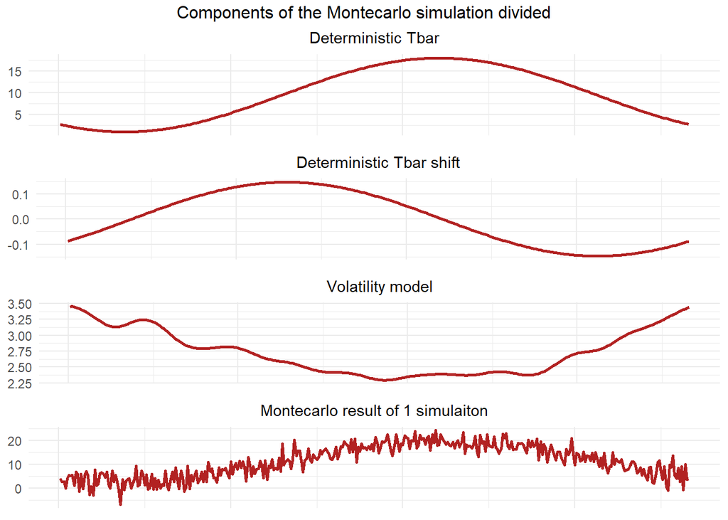

```r
grid.arrange(top = "Components of the Montecarlo simulation divided", ncol = 1,
  quickplot(Tbar_vals, subtitle = "Deterministic Tbar", show_legend = F, linewidth = 1, show_x = F, xlab = NULL, ylab = NULL),
  quickplot(dTbar_vals, subtitle = "Deterministic Tbar shift", show_legend = F, linewidth = 1, show_x = F, xlab = NULL, ylab = NULL),
  quickplot(sigma_vals, subtitle = "Volatility model", show_legend = F, linewidth = 1, show_x = F, xlab = NULL, ylab = NULL),
  quickplot(monte_carlo_temp(trading_dates_year, Tbar_params, vol_df, first_ordinal_val, M = 2)$mc_sims[2], subtitle = "Montecarlo result of 1 simulaiton", show_legend = F, linewidth = 1, show_x = F, xlab = F, ylab = NULL))
```

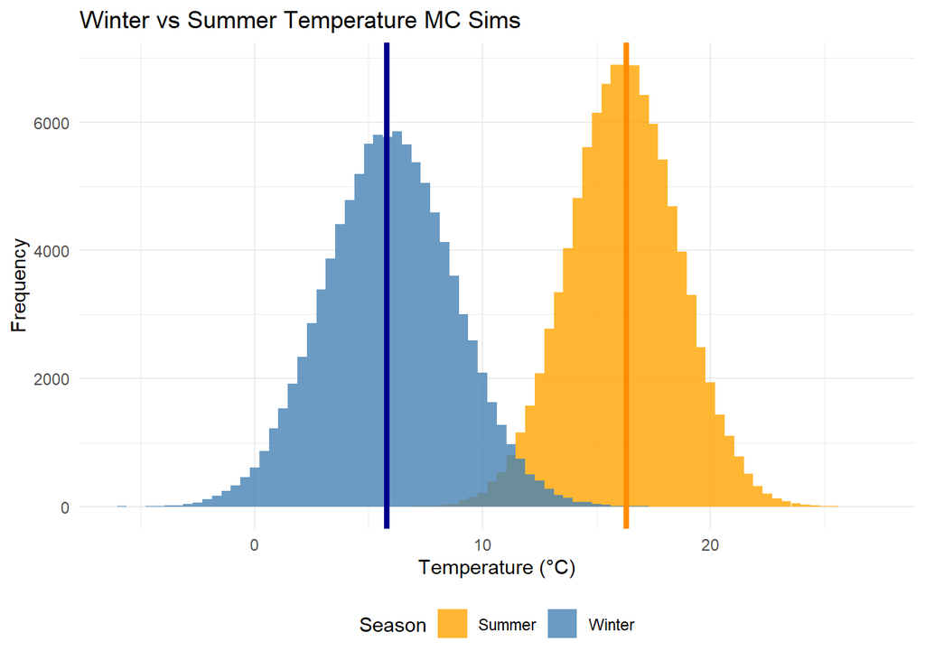

```r
# Set number of simulations
no_sims <- 100000

# Define winter and summer dates
trading_dates_winter <- as.Date("2025-04-01")
trading_dates_summer <- as.Date("2025-10-01")

# Run simulations
sim_results_winter <- monte_carlo_temp(trading_dates_winter, Tbar_params, vol_df, first_ordinal_val, M = no_sims)
sim_results_summer <- monte_carlo_temp(trading_dates_summer, Tbar_params, vol_df, first_ordinal_val, M = no_sims)


# Extract results
mc_sims_winter <- sim_results_winter$mc_sims %>% select(-Date)
mc_sims_summer <- sim_results_summer$mc_sims %>% select(-Date)

Tbar_summer <- sim_results_summer$mc_temps$Tbar[1]
Tbar_winter <- sim_results_winter$mc_temps$Tbar[1]

# Create combined data frame for plotting
plot_data <- bind_rows(
  data.frame(Temperature = unlist(mc_sims_summer), Season = "Summer"),
  data.frame(Temperature = unlist(mc_sims_winter), Season = "Winter")
)

# Create the plot
ggplot(plot_data, aes(x = Temperature, fill = Season)) +
  geom_histogram(position = "identity", alpha = 0.8, bins = 80) +
  geom_vline(aes(xintercept = Tbar_winter), color = "darkblue",
              linewidth = 1.5, linetype = "solid") +
  geom_vline(aes(xintercept = Tbar_summer), color = "darkorange",
              linewidth = 1.5, linetype = "solid") +
  scale_fill_manual(values = c(Winter="steelblue", Summer="orange")) +
  labs(title = "Winter vs Summer Temperature MC Sims",
        x = "Temperature (°C)",
        y = "Frequency") +
  theme_minimal() +
  theme(legend.position = "bottom")
```

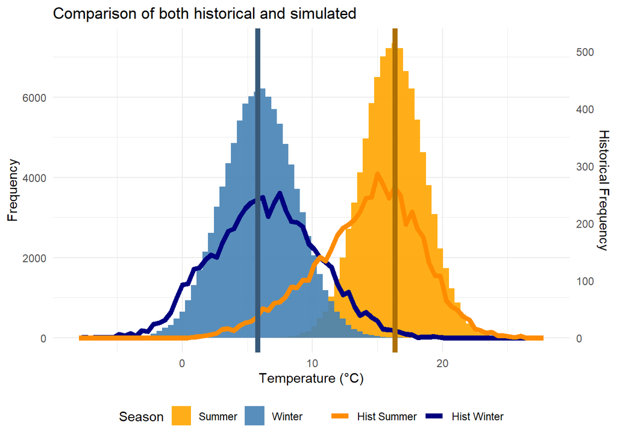

```r
# Create the plot
ggplot(plot_data, aes(x = Temperature, fill = Season)) +
  geom_histogram(position = "identity", alpha = 0.9, bins = 80) +
  geom_freqpoly(data=winter_dataset, aes(x = T_AVG, y = after_stat(count*10), color = "Hist Winter"),  bins = 80, linewidth = 2)+
  geom_freqpoly(data=summer_dataset, aes(x = T_AVG, y = after_stat(count*10), color = "Hist Summer"),  bins = 80, linewidth = 2)+
  geom_vline(aes(xintercept = Tbar_winter), color = darken("steelblue", 0.3), linewidth = 2, linetype = "solid") +
  geom_vline(aes(xintercept = Tbar_summer), color = darken("orange", 0.3), linewidth = 2, linetype = "solid") +
  scale_fill_manual(values = c(Winter = "steelblue", Summer = "orange")) +
  scale_color_manual(name = NULL, values = c("Hist Winter" = "navy", "Hist Summer" = "darkorange")) +
  labs(title = "Comparison of both historical and simulated", x = "Temperature (°C)", y = "Simulated Frequency") +
  theme(legend.position = "bottom") +
  scale_y_continuous(name = "Frequency", sec.axis = sec_axis(~ . * 0.07, name = "Historical Frequency"))
```

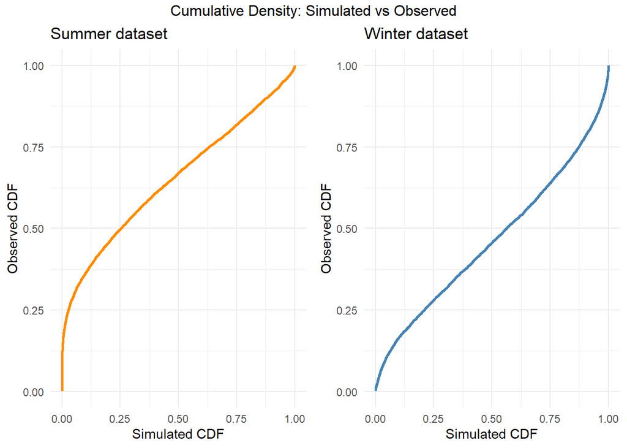

```r
grid.arrange( top = "Cumulative Density: Simulated vs Observed", nrow = 1,
suppressWarnings(compare_cdf(unlist(mc_sims_summer), summer_dataset$T_AVG, "Summer dataset", "darkorange")),
suppressWarnings(compare_cdf(unlist(mc_sims_winter), winter_dataset$T_AVG, "Winter dataset", "steelblue")))
```

# 8 Risk neutral pricing

London’s weather is rather chilly, so, we need to actually structure a contract that makes sense

So we need to compute the probability that the option does not pay out (i.e., temperature Tn stays above 18°C).

```r
temps_checked <- 5:28
prob_no_payout_df <- data.frame(matrix(numeric(length(temps_checked)*3), ncol = 3)) %>%
  set_colnames(c("temps", "summer", "winter"))
prob_no_payout_df[, 1] <- temps_checked

prob_sim_summer <- as.numeric(sim_results_summer$mc_sims[-1])
counter <- 1
for (n in temps_checked) {
  payoffs <- ifelse(prob_sim_summer >= n, 0, n - prob_sim_summer)
  prob_no_payout <- mean(payoffs == 0) * 100
  prob_no_payout_df[counter,2] <- prob_no_payout
  cat(paste0("Probability P(max(",n,"-Tn, 0) = 0): ", prob_no_payout, "%","\n"))
  counter <- counter+1
}
```

```
Probability P(max(5-Tn, 0) = 0): 100%
Probability P(max(6-Tn, 0) = 0): 99.999%
Probability P(max(7-Tn, 0) = 0): 99.994%
Probability P(max(8-Tn, 0) = 0): 99.973%
Probability P(max(9-Tn, 0) = 0): 99.88%
Probability P(max(10-Tn, 0) = 0): 99.552%
Probability P(max(11-Tn, 0) = 0): 98.571%
Probability P(max(12-Tn, 0) = 0): 96.16%
Probability P(max(13-Tn, 0) = 0): 91.009%
Probability P(max(14-Tn, 0) = 0): 82.312%
Probability P(max(15-Tn, 0) = 0): 69.339%
Probability P(max(16-Tn, 0) = 0): 53.403%
Probability P(max(17-Tn, 0) = 0): 36.931%
Probability P(max(18-Tn, 0) = 0): 22.636%
Probability P(max(19-Tn, 0) = 0): 12.054%
Probability P(max(20-Tn, 0) = 0): 5.593%
Probability P(max(21-Tn, 0) = 0): 2.232%
Probability P(max(22-Tn, 0) = 0): 0.728%
Probability P(max(23-Tn, 0) = 0): 0.234%
Probability P(max(24-Tn, 0) = 0): 0.066%
Probability P(max(25-Tn, 0) = 0): 0.017%
Probability P(max(26-Tn, 0) = 0): 0.003%
Probability P(max(27-Tn, 0) = 0): 0.001%
Probability P(max(28-Tn, 0) = 0): 0%
```

```r
prob_sim_winter <- as.numeric(sim_results_winter$mc_sims[-1])

counter <- 1
for (n in temps_checked) {
    payoffs <- ifelse(prob_sim_winter <= n, 0, n - prob_sim_winter)
  prob_no_payout <- mean(payoffs == 0) * 100
  cat(paste0("Probability P(max(",n,"-Tn, 0) = 0): ", prob_no_payout, "%","\n"))
  prob_no_payout_df[counter,3] <- prob_no_payout
  counter <- counter+1
}
```

```
Probability P(max(5-Tn, 0) = 0): 37.311%
Probability P(max(6-Tn, 0) = 0): 51.142%
Probability P(max(7-Tn, 0) = 0): 64.845%
Probability P(max(8-Tn, 0) = 0): 76.803%
Probability P(max(9-Tn, 0) = 0): 86.261%
Probability P(max(10-Tn, 0) = 0): 92.618%
Probability P(max(11-Tn, 0) = 0): 96.408%
Probability P(max(12-Tn, 0) = 0): 98.439%
Probability P(max(13-Tn, 0) = 0): 99.372%
Probability P(max(14-Tn, 0) = 0): 99.783%
Probability P(max(15-Tn, 0) = 0): 99.934%
Probability P(max(16-Tn, 0) = 0): 99.982%
Probability P(max(17-Tn, 0) = 0): 99.997%
Probability P(max(18-Tn, 0) = 0): 99.999%
Probability P(max(19-Tn, 0) = 0): 100%
Probability P(max(20-Tn, 0) = 0): 100%
Probability P(max(21-Tn, 0) = 0): 100%
Probability P(max(22-Tn, 0) = 0): 100%
Probability P(max(23-Tn, 0) = 0): 100%
Probability P(max(24-Tn, 0) = 0): 100%
Probability P(max(25-Tn, 0) = 0): 100%
Probability P(max(26-Tn, 0) = 0): 100%
Probability P(max(27-Tn, 0) = 0): 100%
Probability P(max(28-Tn, 0) = 0): 100%
```

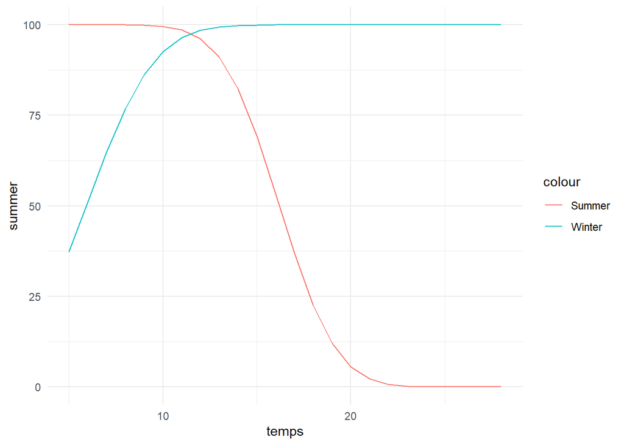

```r
ggplot(prob_no_payout_df, aes(x = temps))+
  geom_line(aes(y = summer, color = "Summer"))+
  geom_line(aes(y = winter, color = "Winter"))
```

## 8.1 Market model

The market for weather derivatives is a typical example of an incomplete market, because the underlying variable, the temperature, is not tradable. Therefore we have to consider the market price of risk $\lambda$, in order to obtain unique prices for such contracts.

Since there is not yet a real market from which we can obtain prices, we assume for simplicity that the market price of risk is constant. Furthermore, we assume that we are given a risk free asset with constant interest rate $r$ and a contract that for each degree Celsius pays one unit of currency. Thus, under a martingale measure $\mathbb{Q}$, characterized by the market price of risk $\lambda$, our price process also denoted by $T_t$ satisfies the following dynamics:

So under risk neutral probability it becomes

$$dT_t^\mathbb{Q}=\left(\frac{d\bar T_t}{dt}+κ(\bar T_t−T_t)-\lambda\sigma _t \right)dt + σ_t\ dW^Q_t$$

Compared to the physical probability measure

$$dT_t^\mathbb{P}=\left(\frac{d\bar T_t}{dt}+κ(\bar T_t−T_t) \right)dt + σ_t\ dW^P_t$$

Only losing the $-\lambda\sigma _t$ term

For simplicity’s sake i’m just doing Montecarlo valuation as some other researchers did not find much difference with analytical valuation of the Black and Scholes closed form stochastic calculus method

```r
temperature_option <- function(trading_dates, no_sims, Tbar_params, vol_df,
r = 0.05, alpha = 2500, K = 300, T_maturity = 1, first_ordinal = first_ordinal_val, option_type = "call", ref_temperature = 18) {
  T_maturity_mod <- (max(as.numeric(trading_dates))-min(as.numeric(trading_dates)))/365.25
  if (T_maturity==1) {
    T_maturity <- T_maturity_mod
  }
  # Run Monte Carlo temperature simulation (assumes your R version exists)
  mc_res <- monte_carlo_temp(trading_dates, Tbar_params, vol_df, first_ordinal, no_sims)
  mc_sims <- mc_res$mc_sims   # matrix/dataframe of simulated temps

  M <- ncol(mc_sims)  # number of simulations
  N <- nrow(mc_sims)  # number of time steps (not directly needed)

  mc_arr <- as.matrix(mc_sims[,-1])

  # Cooling degree days (CDD) or similar metric
  DD <- colSums(pmax(ref_temperature - mc_arr, 0))

  # Option payoff
  if (option_type == "call") {
    Payoff <- alpha * pmax(DD - K, 0)
  } else {
    Payoff <- alpha * pmax(K - DD, 0)
  }

  # Discounted expected payoff
  C0 <- exp(-r * T_maturity) * mean(Payoff)

  # Standard error of estimator
  sigma <- sqrt(sum((exp(-r * T_maturity) * Payoff - C0)^2) / (M - 1))
  SE <- sigma / sqrt(M)

  return(list(price = C0, se = SE))
}

trading_dates <- seq(as.Date("2024-12-01"), as.Date("2025-03-01"), by = "day")

temperature_option(trading_dates, 10000, Tbar_params, vol_df, r = 0.05, alpha = 2500, K = 300, T_maturity = 1, first_ordinal, option_type = "put", ref_temperature = 18) %>% bprint()
```

```
price = 0
se = 0
```

```r
temperature_option(trading_dates, 10000, Tbar_params, vol_df, r = 0.05, alpha = 2500, K = 300, T_maturity = 1, first_ordinal, option_type = "call", ref_temperature = 18) %>% bprint()
```

```
price = 2409712
se = 760.5388
```

```r
cat("maturity =", (max(as.numeric(trading_dates))-min(as.numeric(trading_dates)))/365.25, "years")
```

```
maturity = 0.2464066 years
```

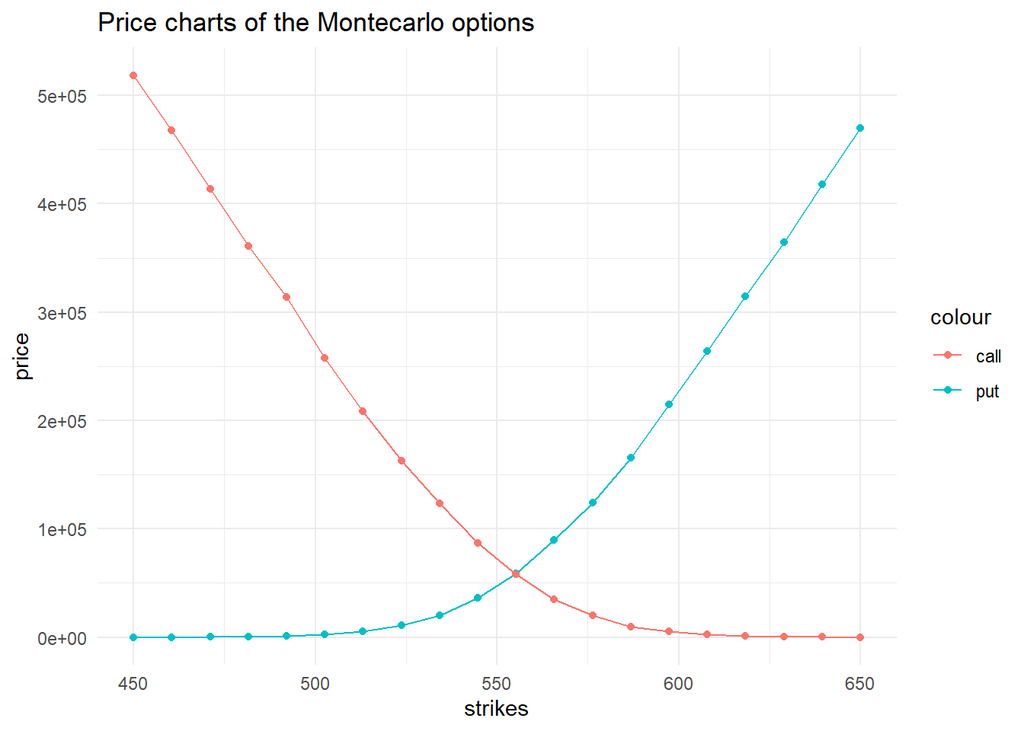

```r
strikes <- seq(450,650, length.out = 20)
ref_t <- 10
nsim <- 10000
alpha <- 5000
prices_options <- data.frame(matrix(numeric(length(strikes)*4),ncol = 4)) %>%
  set_colnames(c("put", "call", "SE_put", "SE_call"))
counter <- 1
for (i in strikes) {
 PUT <- temperature_option(trading_dates, nsim, Tbar_params, vol_df, ref_temperature = ref_t, K = i, option_type = "put", alpha = alpha)
  CALL <- temperature_option(trading_dates, nsim, Tbar_params, vol_df, ref_temperature = ref_t, K = i, option_type = "call", alpha = alpha)

  prices_options[counter,1] <- PUT$price
  prices_options[counter,2] <- CALL$price
  prices_options[counter,3] <- PUT$se
  prices_options[counter,4] <- CALL$se
counter <- counter+1
}

ggplot(cbind(prices_options,strikes), aes(x = strikes))+
  geom_line(aes(y = put,  color = "put")) +
    geom_point(aes(y = put,  color = "put")) +
  geom_line(aes(y = call, color = "call")) +
    geom_point(aes(y = call, color = "call")) +
    labs(title = "Price charts of the Montecarlo options", y = "price")
```

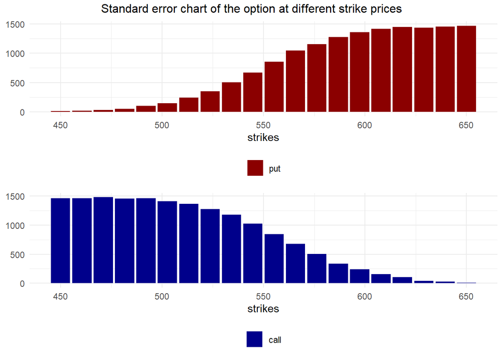

```r
grid.arrange(top = "Standard error chart of the option at different strike prices",
  ggplot(cbind(prices_options,strikes), aes(x = strikes))+
    geom_col(aes(y = SE_put,  fill = "put")) +
    scale_fill_manual(NULL, values = "darkred") +
    ylab(NULL) +
    theme(legend.position = "bottom"),

  ggplot(cbind(prices_options,strikes), aes(x = strikes))+
    geom_col(aes(y = SE_call, fill = "call"))+
    ylab(NULL) +
    scale_fill_manual(NULL, values = "darkblue")+
    theme(legend.position = "bottom")
)
```

```r
# Add this debug code:
mc_res <- monte_carlo_temp(trading_dates, Tbar_params, vol_df, first_ordinal, 100)
mc_sims <- mc_res$mc_sims   # matrix/dataframe of simulated temps
M <- ncol(mc_sims)  # number of simulations
N <- nrow(mc_sims)  # number of time steps (not directly needed)
mc_arr <- as.matrix(mc_sims[,-1])

dd_sample <- colSums(pmax(ref_t - mc_arr, 0))
cat("DD stats: mean =", mean(dd_sample), ", range =", range(dd_sample), "\n")
```

```
DD stats: mean = 556.1695 , range = 496.1969 636.7569
```

```r
cat("Strikes in range?", any(strikes > min(dd_sample) & strikes < max(dd_sample)), "\n")
```

```
Strikes in range? TRUE
```

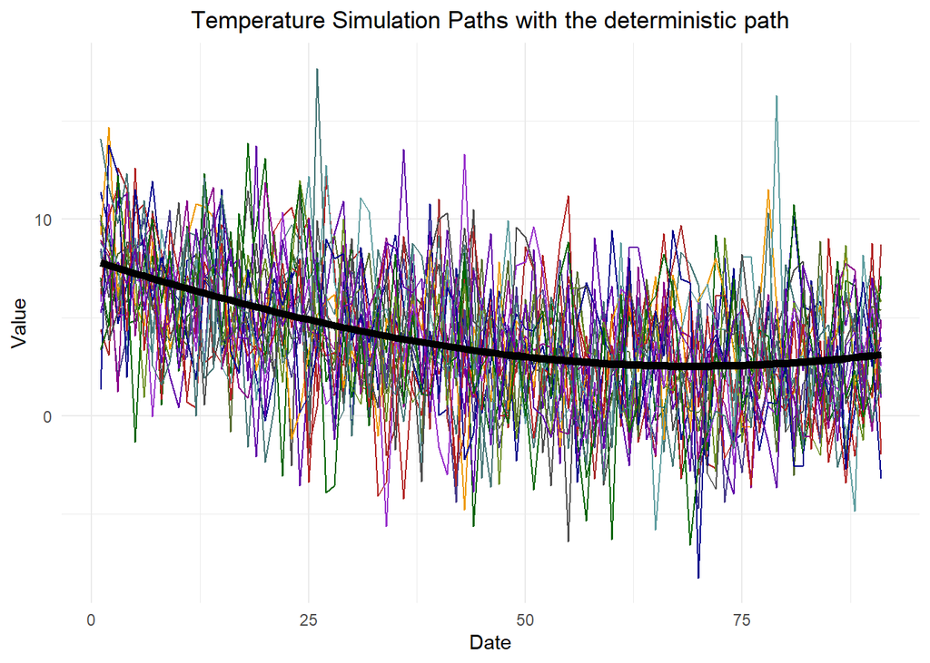

```r
quickplot(mc_res$mc_sims[, -1][1:20], show_legend = F,
  title = "Temperature Simulation Paths with the deterministic path") +
  geom_line(
    data = data.frame(x = 1:length(trading_dates), y = mc_res$mc_temps$Tbar),
    aes(x = x, y = y),
    color = "black",
    linewidth = 2
  )
```

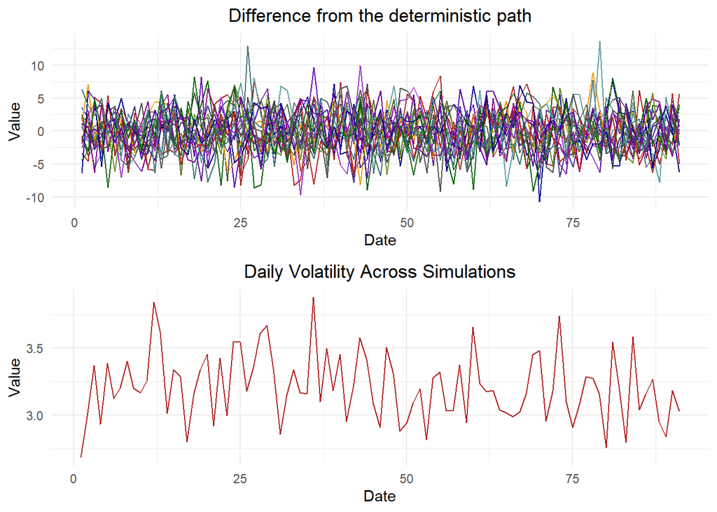

```r
temp_diffs <- apply(mc_arr, 2, function(x) x - mc_res$mc_temps$Tbar)[, 1:20]
daily_vol <- apply(mc_arr, 1, sd)

grid.arrange(
  quickplot(temp_diffs, title = "Difference from the deterministic path", show_legend = F),
  quickplot(daily_vol, title = "Daily Volatility Across Simulations", show_legend = F)
)
```

```r
cat("Mean deviation from seasonal average:", mean(abs(temp_diffs)), "\n")
```

```
Mean deviation from seasonal average: 2.58984
```

```r
cat("Volatility range:", range(daily_vol), "\n")
```

```
Volatility range: 2.677122 3.8814
```

## 8.2 Greek Numerical Approximations

Since we aren’t dealing with plain vanilla options the only option to calculate geeks is to do them via Numerical Approximations using:

$$\text{Greek} \approx \frac{V(x + \varepsilon) - V(x - \varepsilon)}{2\varepsilon}$$

Where:

$x$ is the input variable $\varepsilon$ is a small shift

This is a finite difference approach: generalizable and useful when analytical Greeks are unavailable

This method works for any option and it still assumes that the function is smooth and approximable locally, like the ones coming from the closed form solution of the Black and Scholes model but it breaks down with large shocks.

All this has been done with an $\alpha = 1$ to not have a magnifying effect on the value due to the price per tick being generally very expensive

- Greeks give powerful local sensitivities
- Good for quick P&L estimates, hedging, and risk management

**Temperature Sensitivity Delta** Shock the baseline temperature parameter ‘a’ akin to a change in price

```r
shock <- 0.1
params_up <- Tbar_params
params_down <- Tbar_params
params_up$a <- Tbar_params$a + shock
params_down$a <- Tbar_params$a - shock

price_up   <- temperature_option(trading_dates, 1000, params_up, vol_df, option_type = "call"  , alpha = 1)$price
price_down <- temperature_option(trading_dates, 1000, params_down, vol_df, option_type = "call", alpha = 1)$price

delta <- (price_up - price_down) / (2 * shock)

data.frame(price_up, price_down, delta) %>%
  gt() %>% cols_label(price_up = "Price up", price_down = "Price down", delta = "Delta") %>%
  opt_stylize(5) %>% tab_header(paste("Delta with shock =",shock))
```

Delta with shock = 0.1

| Price up | Price down | Delta |
| --- | --- | --- |
| 955.2647 | 972.3985 | -85.66901 |

**Volatility Sensitivity Vega** Achieved by changing the fitted volatility function

```r
shock <- 0.1
vol_up <- vol_df
vol_down <- vol_df
vol_up$fvol <- vol_df$fvol + shock
vol_down$fvol <- vol_df$fvol - shock

price_up   <- temperature_option(trading_dates, 1000, params_up, vol_up, option_type = "call"  , alpha = 1)$price
price_down <- temperature_option(trading_dates, 1000, params_down, vol_down, option_type = "call", alpha = 1)$price

vega <- (price_up - price_down) / (2 * shock)

data.frame(price_up, price_down, vega) %>%
  gt() %>% cols_label(price_up = "Price up", price_down = "Price down", vega = "Vega") %>%
  opt_stylize(5) %>% tab_header(paste("Vega with shock =",shock))
```

Vega with shock = 0.1

| Price up | Price down | Vega |
| --- | --- | --- |
| 954.807 | 974.3841 | -97.88553 |

**Seasonality Sensitivity (Alpha Sensitivity)** Sensitivity to seasonal amplitude changes Where the negative shock means that the data is more seasonal

```r
shock <- 0.1
params_up <- Tbar_params
params_down <- Tbar_params
params_up$alpha <- Tbar_params$alpha + shock
params_down$alpha <- Tbar_params$alpha - shock

price_up   <- temperature_option(trading_dates, 1000, params_up, vol_df, option_type = "call"  , alpha = 1)$price
price_down <- temperature_option(trading_dates, 1000, params_down, vol_df, option_type = "call", alpha = 1)$price

alpha_g <- (price_up - price_down) / (2 * shock)

data.frame(price_up, price_down, alpha_g) %>%
  gt() %>% cols_label(price_up = "Price up", price_down = "Price down", alpha_g = "Alpha greek") %>%
  opt_stylize(5) %>% tab_header(paste("Seasonality greek with shock =",shock))
```

Seasonality greek with shock = 0.1

| Price up | Price down | Alpha greek |
| --- | --- | --- |
| 973.0939 | 955.584 | 87.5496 |

**Reference Temperature Greek** Now we are more in the realm of contract modifications which are not possible but stil greek as we are just changing a parameter

```r
shock <- 3
price_up   <- temperature_option(trading_dates, 1000, Tbar_params, vol_df, option_type = "call", alpha = 1, ref_temperature = 18+shock)$price
price_down <- temperature_option(trading_dates, 1000, Tbar_params, vol_df, option_type = "call", alpha = 1, ref_temperature = 18-shock)$price

temp_g <- (price_up - price_down) / (2 * shock)

data.frame(price_up, price_down, temp_g) %>%
  gt() %>% cols_label(price_up = "Price up", price_down = "Price down", temp_g = "Reference T Greek") %>%
  opt_stylize(5) %>% tab_header(paste("Reference Temperature Greek with shock =",shock))
```

Reference Temperature Greek with shock = 3

| Price up | Price down | Reference T Greek |
| --- | --- | --- |
| 1232.366 | 694.2161 | 89.6916 |

**Time passing Sensitivity ( $\Theta$ )** This is probably the most out there since unlike financial options where time decay is purely about discounting, temperature derivatives have path-dependent payoffs. When you shorten the period, you’re not just reducing time to expiration - you’re fundamentally changing the underlying (total degree days accumulated).

```r
days_elapsed <- 3

price_t0 <- temperature_option(trading_dates, 1000, Tbar_params, vol_df, option_type = "call", alpha = 1)$price

# Option after some days have passed (shorter remaining period)
remaining_dates <- trading_dates[(days_elapsed):length(trading_dates)]
price_t1 <- temperature_option(remaining_dates, 1000, Tbar_params, vol_df, option_type = "call", alpha = 1)$price

theta <- (price_t1 - price_t0) / days_elapsed

data.frame(price_up, price_down, temp_g) %>%
  gt() %>% cols_label(price_up = "Price T0", price_down = "Price T1", temp_g = "Reference T Greek") %>%
  opt_stylize(5) %>% tab_header(paste("Theta with shock =", days_elapsed))
```

Theta with shock = 3

[output not shown]

# 9 Sidequests

## 9.1 Sidequest: predicting temperatures in the future

```r
model_formula <- function(t, a, b, a1, b1) {
  omega <- 2 * pi / 365.25
  a + b * t + a1 * cos(omega * t) + b1 * sin(omega * t)
}

forecast_N <- 30
new_t <- max(temps$NUM_DAY) + forecast_N  # forecast_N days after last observation
predicted_T <- model_formula(new_t, MOD_params["a"], MOD_params["b"], MOD_params["alpha"], MOD_params["theta"])
cat("predicted temperature for", as.character(max(temps$DAY)+forecast_N), "=", predicted_T)
```

```
predicted temperature for 2025-10-09 = 15.22176
```

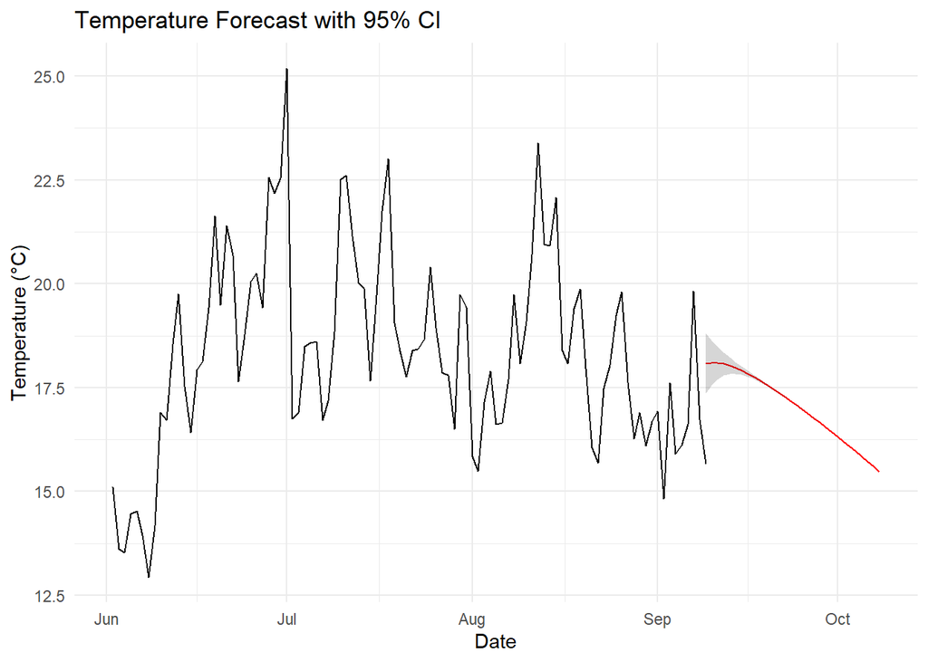

```r
arima_model <- Arima(temps$RESID, order = c(2, 0, 0), include.mean = FALSE)
future_residuals <- forecast(arima_model, h = forecast_N)  # forecast_N steps ahead

first_date <- min(temps$DAY)
future_dates <- seq(max(temps$DAY), by = "day", length.out = forecast_N)
future_t <- as.numeric(difftime(future_dates, first_date, units = "days"))

# Deterministic part
deterministic_part <- model_formula(future_t, MOD_params["a"], MOD_params["b"], MOD_params["alpha"], MOD_params["theta"])

# Stochastic part (residuals)
stochastic_part <- future_residuals$mean

# Final prediction
future_T <- deterministic_part + stochastic_part

forecast_df <- data.frame(
  Date = future_dates,
  Temperature = future_T,
  Lower = future_T - 1.96 * future_residuals$mean,  # 95% CI
  Upper = future_T + 1.96 * future_residuals$mean
)

ggplot() +
  geom_line(data = tail(temps, 100), aes(x = DAY, y = T_AVG)) +
  geom_line(data = forecast_df, aes(x = Date, y = Temperature), color = "red") +
  geom_ribbon(data = forecast_df, aes(x = Date, ymin = Lower, ymax = Upper), alpha = 0.2) +
  labs(title = "Temperature Forecast with 95% CI", y = "Temperature (°C)", x = "Date")
```

Forecast implications:

for forecasting purposes it means a couple of things: that in the short-term my Residuals adjust for recent “shocks” (e.g., a heatwave/cold snap), but in the long-term the forecast relies entirely on the deterministic component (trend + seasonality).

This model doesn’t really account for Volatility clustering, like how temperature tends to have time-varying volatility (e.g., summer vs. winter variability). which is the part of the OU that we still need to model

## 9.2 forecast seasonal plots

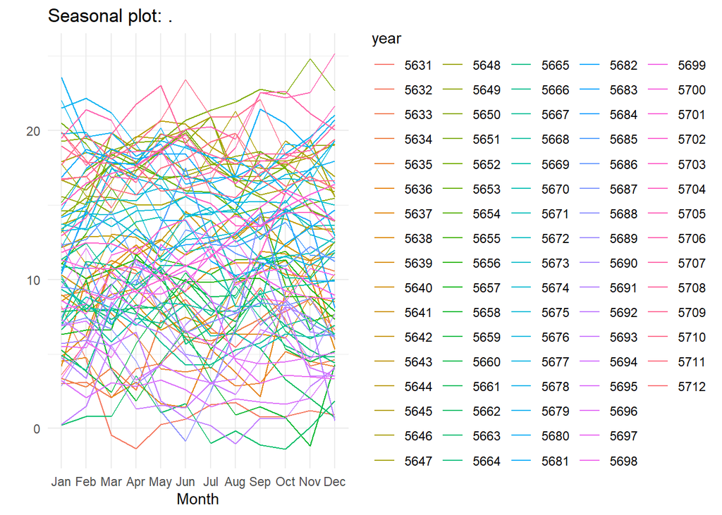

```r
ts(data = temps$T_AVG, frequency = 12, start = temps$DAY[1]) %>% tail(365*2+ last(temps$DOY)) %>% forecast::ggseasonplot()
```

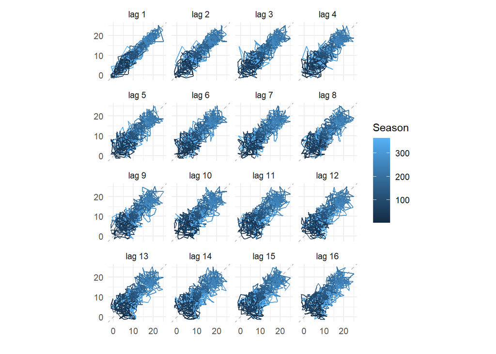

```r
ts(data = temps$T_AVG, frequency = 365, start = temps$DAY[1]) %>% tail(365*2+ last(temps$DOY)) %>% forecast::gglagplot()
```

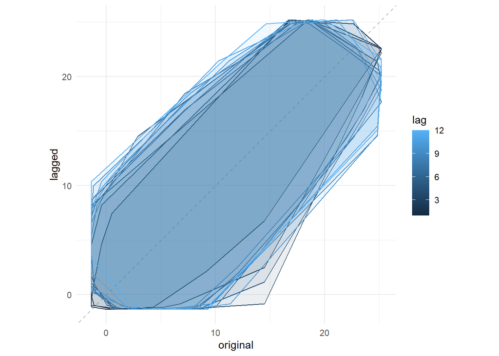

```r
ts(data = temps$T_AVG, frequency = 365.25, start = temps$DAY[1]) %>% tail(365*2+ last(temps$DOY)) %>% forecast::gglagchull()
```

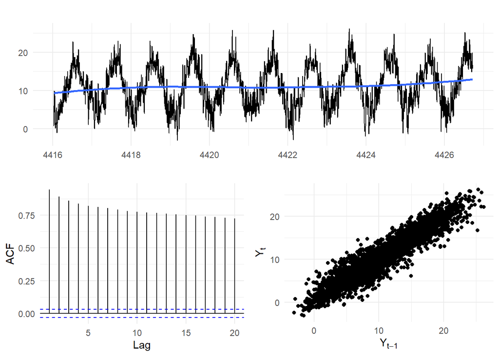

```r
ts(data = temps$T_AVG, frequency = 365, start = temps$DAY[1]) %>% tail(365*10+ last(temps$DOY)) %>% forecast::ggtsdisplay(plot.type = "scatter", points = F, smooth = T, lag.max = 20, theme=theme_minimal())
```

## 9.3 Milan comparison

i just moved from milan and was wondering about the distribution of climate here versus the one from milan

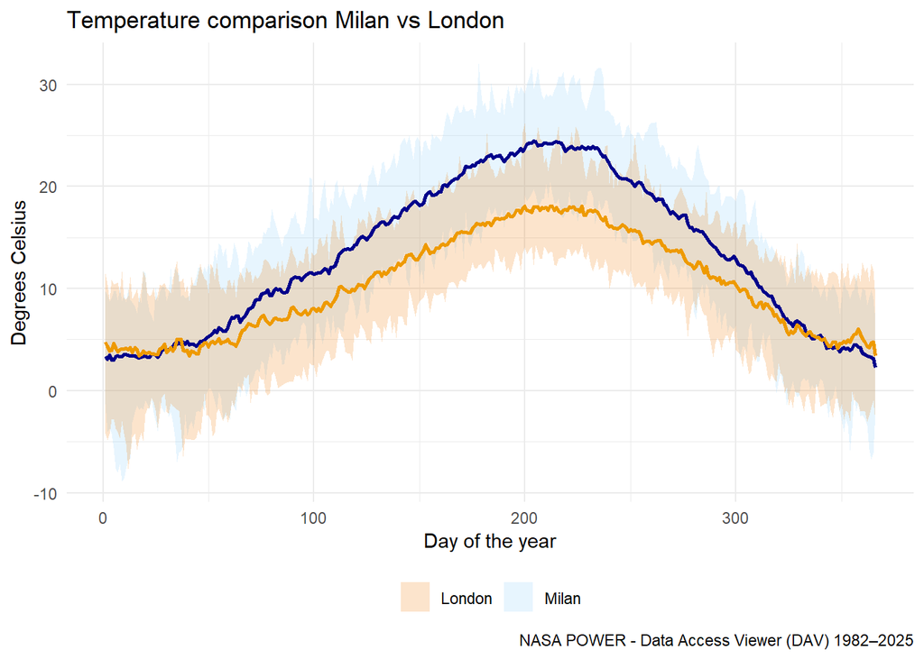

```r
MILAN_RAW <- read.csv("Milan_DATA.csv", skip = 10)

MIL_DATASET <- MILAN_RAW %>%
  mutate(
    T_MAX = remove_outliers(T2M_MAX, fill = "NA") %>% na.approx(),
    T_MIN = remove_outliers(T2M_MIN, fill = "NA") %>% na.approx(),
    DAY   = as.Date(DOY - 1, origin = paste0(YEAR, "-01-01")),
    Month = month(DAY),
    T_AVG = (T_MAX + T_MIN) / 2
  ) %>%
  select(DAY, YEAR, Month, DOY, T_MAX, T_MIN, T_AVG)

# Pivot just once for Milan (average only)
MIL_pivot_df <- MIL_DATASET %>%
  select(DOY, YEAR, T_AVG) %>%
  pivot_wider(names_from = YEAR, values_from = T_AVG)

# Build comparison dataset (Milan + London summary stats)
FD <- data.frame(
  DOY      = MIL_pivot_df$DOY,
  MIL_MIN  = apply(MIL_pivot_df[-1], 1, min, na.rm = TRUE),
  MIL_MAX  = apply(MIL_pivot_df[-1], 1, max, na.rm = TRUE),
  MIL_MEAN = apply(MIL_pivot_df[-1], 1, mean, na.rm = TRUE),
  LON_MIN  = apply(pivot_df[-1], 1, min, na.rm = TRUE),
  LON_MAX  = apply(pivot_df[-1], 1, max, na.rm = TRUE),
  LON_MEAN = apply(pivot_df[-1], 1, mean, na.rm = TRUE)
)

# Plot comparison
ggplot(FD, aes(x = DOY)) +
  geom_ribbon(aes(ymin = MIL_MIN, ymax = MIL_MAX, fill = "Milan"), alpha = 0.2) +
  geom_ribbon(aes(ymin = LON_MIN, ymax = LON_MAX, fill = "London"), alpha = 0.2) +
  geom_line(aes(y = MIL_MEAN, color = "Milan Avg"), linewidth = 1) +
  geom_line(aes(y = LON_MEAN, color = "London Avg"), linewidth = 1) +
  scale_color_manual(name = NULL, values = c("Milan Avg" = "darkblue", "London Avg" = "orange2")) +
  scale_fill_manual(name = NULL, values = c(Milan = "lightskyblue", London = "darkorange2")) +
  labs(
    title = "Temperature comparison Milan vs London",
    y = "Degrees Celsius",
    x = "Day of the year",
    caption = "NASA POWER - Data Access Viewer (DAV) 1982–2025"
  ) +
  theme(legend.position = "bottom") +
  guides(color = "none")
```

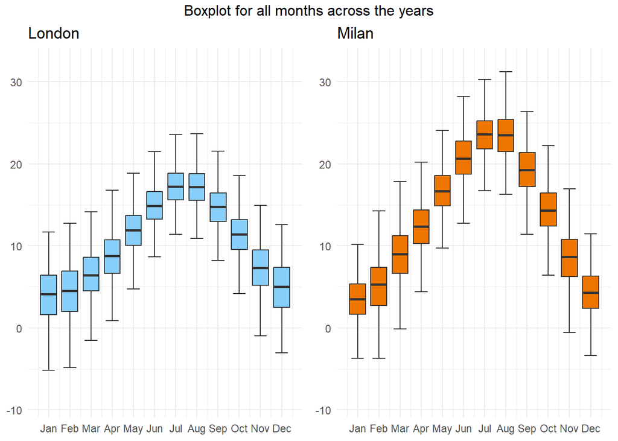

```r
minn <- min(FD$LON_MIN, FD$MIL_MIN)
maxx <- max(FD$LON_MAX, FD$MIL_MAX)

grid.arrange(
  top = "Boxplot for all months across the years",
  nrow = 1,
  DATASET %>%
    select(Month, T_AVG) %>%
    group_by(Month) %>%
    ggplot(aes(x = Month, y = T_AVG, group = Month)) +
    geom_boxplot(fill = "lightskyblue", outliers = FALSE, staplewidth = 0.8) +
    scale_x_continuous(breaks = seq(1, 12, by = 1), labels = month.abb) +
    labs(title = "London", x = NULL, y = NULL) +
    ylim(minn, maxx)
    ,

  MIL_DATASET %>%
    select(Month, T_AVG) %>%
    group_by(Month) %>%
    ggplot(aes(x = Month, y = T_AVG, group = Month)) +
    geom_boxplot(fill = "darkorange2", outliers = FALSE, staplewidth = 0.8) +
    scale_x_continuous(breaks = seq(1, 12, by = 1), labels = month.abb) +
    labs(title = "Milan", x = NULL, y = NULL) +
    ylim(minn, maxx)
)
```